# chapter 5 Summarization Lab B

Odlin Montila

##### Remember to change the `author:` field on this Rmd file to your own name.

We’ll begin by doing all the same data processing as in lecture.

```r
library(MASS)

# Assign more descriptive variable names
colnames(birthwt) <- c("birthwt.below.2500", "mother.age", "mother.weight",
    "race", "mother.smokes", "previous.prem.labor", "hypertension", "uterine.irr",
    "physician.visits", "birthwt.grams")

# Assign more descriptive factor levels and convert variables to factors as needed
library(plyr)
birthwt <- transform(birthwt,
            race = as.factor(mapvalues(race, c(1, 2, 3),
                              c("white","black", "other"))),
            mother.smokes = as.factor(mapvalues(mother.smokes,
                              c(0,1), c("no", "yes"))),
            hypertension = as.factor(mapvalues(hypertension,
                              c(0,1), c("no", "yes"))),
            uterine.irr = as.factor(mapvalues(uterine.irr,
                              c(0,1), c("no", "yes"))),
            birthwt.below.2500 = as.factor(mapvalues(birthwt.below.2500,
                              c(0,1), c("no", "yes")))
            )
```

#### 1. aggregate() vs tapply()

One of the advantages of aggregate() is that it makes it easier to view summary tables when grouping on more than two factors.

**(a)** Use the `tapply()` function to calculate mean `birthwt.grams` grouped by race, mother’s smoking status, and hypertension.

```r
with(birthwt, tapply(birthwt.grams, list(race, mother.smokes, hypertension), FUN = mean))
```

```
## , , no
##
##             no      yes
## black 2813.357 2656.111
## other 2874.824 2757.167
## white 3436.395 2819.292
##
## , , yes
##
##           no    yes
## black 3142.5 1135.0
## other 2063.0     NA
## white 3100.0 2917.5
```

**(b)** Repeat part (a), this time using the `aggregate()` function.

```r
aggregate(birthwt.grams ~ race + mother.smokes + hypertension, FUN = mean, data = birthwt)
```

```
##     race mother.smokes hypertension birthwt.grams
## 1  black            no           no      2813.357
## 2  other            no           no      2874.824
## 3  white            no           no      3436.395
## 4  black           yes           no      2656.111
## 5  other           yes           no      2757.167
## 6  white           yes           no      2819.292
## 7  black            no          yes      3142.500
## 8  other            no          yes      2063.000
## 9  white            no          yes      3100.000
## 10 black           yes          yes      1135.000
## 11 white           yes          yes      2917.500
```

#### 2. by() practice

In today’s lecture we used the `by()` function to calculate the correlation between mother’s age and birth weight broken down by mother’s smoking status. Here’s the command that was used:

```r
by(data = birthwt[c("birthwt.grams", "mother.age")],
   INDICES = birthwt["mother.smokes"],
   FUN = function(x) {cor(x[,1], x[,2])})
```

```
## mother.smokes: no
## [1] 0.2014558
## --------------------------------------------------------
## mother.smokes: yes
## [1] -0.1441649
```

**(a)** Use the `by()` function to calculate the correlation between mother’s age and birth weight broken down by race.

```r
by(data = birthwt[c("birthwt.grams", "mother.age")],
   INDICES = birthwt["race"],
   FUN = function(x) {cor(x[,1], x[,2])})
```

```
## race: black
## [1] -0.3292695
## --------------------------------------------------------
## race: other
## [1] -0.02926127
## --------------------------------------------------------
## race: white
## [1] 0.1660417
```

**(b)** Does the correlation appear to vary by race?

#### 3. Scatterplot practice

In class we made a pretty nice scatterplot using the following command.

```r
# Make sure that the color-blind palette is defined
cbPalette <- c("#000000", "#E69F00", "#56B4E9", "#009E73", "#F0E442", "#0072B2", "#D55E00", "#CC79A7")

points.base <- c(16, 17) # 16: circle, 17: triangle
cols.base <- cbPalette[2:3] # blue and orange points
point.symbols <- points.base[birthwt$mother.smokes]
point.cols <- cols.base[birthwt$mother.smokes]
with(birthwt, plot(mother.age, birthwt.grams,
                   main="Birth Weight by Mother's Age",
                   xlab="Mother's Age (Years)",
                   ylab="Birth Weight (Grams)",
                   col=point.cols,
                   pch=point.symbols))
legend("bottomright", c("Nonsmoker","Smoker"), col=cols.base, pch=points.base)
```

**(a)** Try to create a similar plot, but instead of using different colors and symbols based on the value of `mother.smokes`, do so based on the value of `race`.

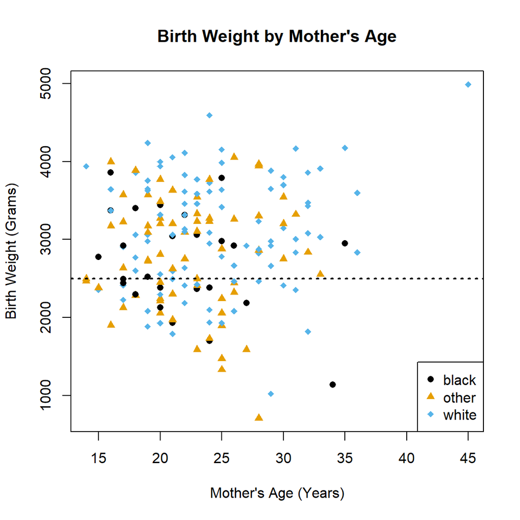

```r
cbPalette <- c("#000000", "#E69F00", "#56B4E9", "#009E73", "#F0E442", "#0072B2", "#D55E00", "#CC79A7")

points.base <- c(16, 17, 18)
cols.base <- cbPalette[1:3]
point.symbols <- points.base[birthwt$race]
point.cols <- cols.base[birthwt$race]
with(birthwt, plot(mother.age, birthwt.grams,
                   main="Birth Weight by Mother's Age",
                   xlab="Mother's Age (Years)",
                   ylab="Birth Weight (Grams)",
                   col=point.cols,
                   pch=point.symbols))
legend("bottomright", legend = levels(birthwt$race), col=cols.base,pch=points.base)
abline(h = 2500, col = cbPalette[1], lty = 3,lwd = 2)
```

**(b)** Use the `abline` command to add a horizontal line to the plot at `birthwt.grams = 2500`.

```r
#the solution is in part a above
```